Kenny TANCHALEUNE, Nicolas Tetsiop, Alain NGMOMEDJ, M1 Big Data

The objective of our dataset is to analyze the sales of video games according to the regions, platform, rating, Critic and year of release.

# Data Cleaning

```python
import pandas as pd
import numpy as np
import matplotlib.pyplot as plt
import seaborn as sns

from pyhive import hive

conn = hive.connect("quickstart.cloudera", username="cloudera")
cursor = conn.cursor()
```

Import of the different libraries useful for our analysis with Hive and connection to cloudera

```python
df = pd.read_csv('videogames.csv')
df.head()
```

|  | Name | Platform | Year_of_Release | Genre | Publisher | NA_Sales | EU_Sales | JP_Sales | Other_Sales | Global_Sales | Critic_Score | Critic_Count | User_Score | User_Count | Developer | Rating; |
| --- | --- | --- | --- | --- | --- | --- | --- | --- | --- | --- | --- | --- | --- | --- | --- | --- |
| 0 | Wii Sports | Wii | 2006.0 | Sports | Nintendo | 41.36 | 28.96 | 3.77 | 8.45 | 82.53 | 76.0 | 51.0 | 8 | 322.0 | Nintendo | E; |
| 1 | Super Mario Bros. | NES | 1985.0 | Platform | Nintendo | 29.08 | 3.58 | 6.81 | 0.77 | 40.24 | NaN | NaN | NaN | NaN | NaN | ; |
| 2 | Mario Kart Wii | Wii | 2008.0 | Racing | Nintendo | 15.68 | 12.76 | 3.79 | 3.29 | 35.52 | 82.0 | 73.0 | 8.3 | 709.0 | Nintendo | E; |
| 3 | Wii Sports Resort | Wii | 2009.0 | Sports | Nintendo | 15.61 | 10.93 | 3.28 | 2.95 | 32.77 | 80.0 | 73.0 | 8 | 192.0 | Nintendo | E; |
| 4 | Pokemon Red/Pokemon Blue | GB | 1996.0 | Role-Playing | Nintendo | 11.27 | 8.89 | 10.22 | 1.00 | 31.37 | NaN | NaN | NaN | NaN | NaN | ; |

Our dataset before cleaning, we can see that there are null values

```python
df.columns
```

```
Index(['Name', 'Platform', 'Year_of_Release', 'Genre', 'Publisher', 'NA_Sales',
       'EU_Sales', 'JP_Sales', 'Other_Sales', 'Global_Sales', 'Critic_Score',
       'Critic_Count', 'User_Score', 'User_Count', 'Developer', 'Rating;'],
      dtype='object')
```

```python
df.rename(columns = {'Other_Sales': 'OtherSales',
                    'Critic_Score': 'CriticScore'}, inplace = True)
```

```python
df.rename(columns = {'Rating;':'Rating'}, inplace = True)
```

We renamed the columns to better see our columns

```python
df.info()
```

```
<class 'pandas.core.frame.DataFrame'>
RangeIndex: 16719 entries, 0 to 16718
Data columns (total 16 columns):
Name               16717 non-null object
Platform           16184 non-null object
Year_of_Release    15926 non-null float64
Genre              16182 non-null object
Publisher          16131 non-null object
NA_Sales           16184 non-null float64
EU_Sales           16184 non-null float64
JP_Sales           16184 non-null float64
OtherSales         16184 non-null float64
Global_Sales       16184 non-null float64
CriticScore        7711 non-null float64
Critic_Count       7711 non-null float64
User_Score         9491 non-null object
User_Count         7173 non-null float64
Developer          9567 non-null object
Rating             16162 non-null object
dtypes: float64(9), object(7)
memory usage: 2.0+ MB
```

```python
df.shape
```

```
(16719, 16)
```

Dataset with 16719 rows and 16 columns before cleaning

```python
df.isna().sum()
```

```
Name                  2
Platform            535
Year_of_Release     793
Genre               537
Publisher           588
NA_Sales            535
EU_Sales            535
JP_Sales            535
OtherSales          535
Global_Sales        535
CriticScore        9008
Critic_Count       9008
User_Score         7228
User_Count         9546
Developer          7152
Rating              557
dtype: int64
```

```python
df = df.dropna()
```

Delete rows where there are null values

```python
df.isna().sum()
```

```
Name               0
Platform           0
Year_of_Release    0
Genre              0
Publisher          0
NA_Sales           0
EU_Sales           0
JP_Sales           0
OtherSales         0
Global_Sales       0
CriticScore        0
Critic_Count       0
User_Score         0
User_Count         0
Developer          0
Rating             0
dtype: int64
```

The Dataset is cleaned. We have 0 null variable, we have a good Video Games Dataset

```python
df.shape
```

```
(6504, 16)
```

Now our dataset had 6504 rows and 16 columns after cleaning

```python
df['Year_of_Release'] = df['Year_of_Release'].astype(np.int64)
```

```python
df = df.drop(df[df.Rating ==';'].index)
```

```python
df['Rating'].replace('AO;','AdultOnly',inplace = True) #AdultOnly = Game for 18+
df['Rating'].replace('E10+;','Everyone 10+',inplace = True) #Everyone 10+ = Game for 10+
df['Rating'].replace('E;','Everyone',inplace = True) #Everyone = Game for 3+
df['Rating'].replace('K-A;','Everyone',inplace = True)#K-A = old everyone. After 1997, they remplace K-A by Everyone
df['Rating'].replace('M','Mature',inplace = True) # Mature = Game for 17+
df['Rating'].replace('M;','Mature',inplace = True)# Mature = Game for 17+
df['Rating'].replace('RP;','RatingPending',inplace = True)# RatingPending = Not yet assigned a final ESRB Rating
df['Rating'].replace('T;','Teen',inplace = True) # Teen = Game for 13+
#Source: https://www.esrb.org/ratings-guide/
```

```python
df.to_csv('videogame99cleaned.csv',index = False)
```

We create another csv file that contains the cleaned datase

```python
data = pd.read_csv('videogame99cleaned.csv')
data.head()
```

|  | Name | Platform | Year_of_Release | Genre | Publisher | NA_Sales | EU_Sales | JP_Sales | OtherSales | Global_Sales | CriticScore | Critic_Count | User_Score | User_Count | Developer | Rating |
| --- | --- | --- | --- | --- | --- | --- | --- | --- | --- | --- | --- | --- | --- | --- | --- | --- |
| 0 | Wii Sports | Wii | 2006 | Sports | Nintendo | 41.36 | 28.96 | 3.77 | 8.45 | 82.53 | 76.0 | 51.0 | 8.0 | 322.0 | Nintendo | Everyone |
| 1 | Mario Kart Wii | Wii | 2008 | Racing | Nintendo | 15.68 | 12.76 | 3.79 | 3.29 | 35.52 | 82.0 | 73.0 | 8.3 | 709.0 | Nintendo | Everyone |
| 2 | Wii Sports Resort | Wii | 2009 | Sports | Nintendo | 15.61 | 10.93 | 3.28 | 2.95 | 32.77 | 80.0 | 73.0 | 8.0 | 192.0 | Nintendo | Everyone |
| 3 | New Super Mario Bros. | DS | 2006 | Platform | Nintendo | 11.28 | 9.14 | 6.50 | 2.88 | 29.80 | 89.0 | 65.0 | 8.5 | 431.0 | Nintendo | Everyone |
| 4 | Wii Play | Wii | 2006 | Misc | Nintendo | 13.96 | 9.18 | 2.93 | 2.84 | 28.92 | 58.0 | 41.0 | 6.6 | 129.0 | Nintendo | Everyone |

We open the cleaned dataset

# HIVE PART

```python
cursor.execute('DROP DATABASE IF EXISTS VIDEOGAME99 CASCADE') # if one was created before
cursor.execute('CREATE DATABASE VIDEOGAME99')
cursor.execute('DROP TABLE IF EXISTS videogame99 ')
cursor.execute("CREATE TABLE IF NOT EXISTS videogame99 (\
Name STRING,\
Platform STRING,\
YearofRelease INT,\
Genre STRING,\
Publisher STRING,\
NASales FLOAT,\
EUSales FLOAT,\
JPSales FLOAT,\
OthersSales FLOAT,\
GlobalSales FLOAT,\
CriticScore FLOAT,\
CriticCount FLOAT,\
UserScore FLOAT,\
UserCount FLOAT,\
Developer STRING,\
Rating STRING)\
ROW FORMAT DELIMITED \
FIELDS TERMINATED BY ','")

cursor.execute("LOAD DATA LOCAL INPATH '/home/cloudera/Downloads/videogame99cleaned.csv' OVERWRITE INTO TABLE videogame99")
cursor.execute('ALTER TABLE videogame99 set \
TBLPROPERTIES ("skip.header.line.count"="1")')
cursor.execute('SET hive.cli.print.header=true')
```

Creating the VIDEOGAME99 database and the videogame99 table

```python
cursor.execute('DESCRIBE videogame99')
query = cursor.fetchall()
query
```

```
[('name', 'string', ''),
 ('platform', 'string', ''),
 ('yearofrelease', 'int', ''),
 ('genre', 'string', ''),
 ('publisher', 'string', ''),
 ('nasales', 'float', ''),
 ('eusales', 'float', ''),
 ('jpsales', 'float', ''),
 ('otherssales', 'float', ''),
 ('globalsales', 'float', ''),
 ('criticscore', 'float', ''),
 ('criticcount', 'float', ''),
 ('userscore', 'float', ''),
 ('usercount', 'float', ''),
 ('developer', 'string', ''),
 ('rating', 'string', '')]
```

Allows to see the information of our table

```python
cursor.execute('SELECT * FROM videogame99')
query = cursor.fetchall()
rows = pd.DataFrame(query, columns=(['Name', 'Platform', 'YearofRelease', 'Genre', 'Publisher', 'NASales', 'EUSales',
                                    'JPSales', 'OtherSales', 'GlobalSales', 'CriticScore', 'CriticCount', 'UserCount',
                                     'UserScore', 'Developer', 'Rating']))
rows
```

|  | Name | Platform | YearofRelease | Genre | Publisher | NASales | EUSales | JPSales | OtherSales | GlobalSales | CriticScore | CriticCount | UserCount | UserScore | Developer | Rating |
| --- | --- | --- | --- | --- | --- | --- | --- | --- | --- | --- | --- | --- | --- | --- | --- | --- |
| 0 | Wii Sports | Wii | 2006 | Sports | Nintendo | 41.360001 | 28.959999 | 3.77 | 8.45 | 82.529999 | 76.0 | 51.0 | 8.0 | 322.0 | Nintendo | Everyone |
| 1 | Mario Kart Wii | Wii | 2008 | Racing | Nintendo | 15.680000 | 12.760000 | 3.79 | 3.29 | 35.520000 | 82.0 | 73.0 | 8.3 | 709.0 | Nintendo | Everyone |
| 2 | Wii Sports Resort | Wii | 2009 | Sports | Nintendo | 15.610000 | 10.930000 | 3.28 | 2.95 | 32.770000 | 80.0 | 73.0 | 8.0 | 192.0 | Nintendo | Everyone |
| 3 | New Super Mario Bros. | DS | 2006 | Platform | Nintendo | 11.280000 | 9.140000 | 6.50 | 2.88 | 29.799999 | 89.0 | 65.0 | 8.5 | 431.0 | Nintendo | Everyone |
| 4 | Wii Play | Wii | 2006 | Misc | Nintendo | 13.960000 | 9.180000 | 2.93 | 2.84 | 28.920000 | 58.0 | 41.0 | 6.6 | 129.0 | Nintendo | Everyone |
| ... | ... | ... | ... | ... | ... | ... | ... | ... | ... | ... | ... | ... | ... | ... | ... | ... |
| 6440 | E.T. The Extra-Terrestrial | GBA | 2001 | Action | NewKidCo | 0.010000 | 0.000000 | 0.00 | 0.00 | 0.010000 | 46.0 | 4.0 | 2.4 | 21.0 | Fluid Studios | Everyone |
| 6441 | Mortal Kombat: Deadly Alliance | GBA | 2002 | Fighting | Midway Games | 0.010000 | 0.000000 | 0.00 | 0.00 | 0.010000 | 81.0 | 12.0 | 8.8 | 9.0 | Criterion Games | Mature |
| 6442 | Metal Gear Solid V: Ground Zeroes | PC | 2014 | Action | Konami Digital Entertainment | 0.000000 | 0.010000 | 0.00 | 0.00 | 0.010000 | 80.0 | 20.0 | 7.6 | 412.0 | Kojima Productions | Mature |
| 6443 | Breach | PC | 2011 | Shooter | Destineer | 0.010000 | 0.000000 | 0.00 | 0.00 | 0.010000 | 61.0 | 12.0 | 5.8 | 43.0 | Atomic Games | Teen |
| 6444 | STORM: Frontline Nation | PC | 2011 | Strategy | Unknown | 0.000000 | 0.010000 | 0.00 | 0.00 | 0.010000 | 60.0 | 12.0 | 7.2 | 13.0 | SimBin | Everyone 10+ |

6445 rows × 16 columns

```python
rows.isna().sum()
```

```
Name             0
Platform         0
YearofRelease    0
Genre            0
Publisher        0
NASales          0
EUSales          0
JPSales          0
OtherSales       0
GlobalSales      0
CriticScore      0
CriticCount      0
UserCount        0
UserScore        0
Developer        0
Rating           0
dtype: int64
```

We check on hive that we have 0 value null

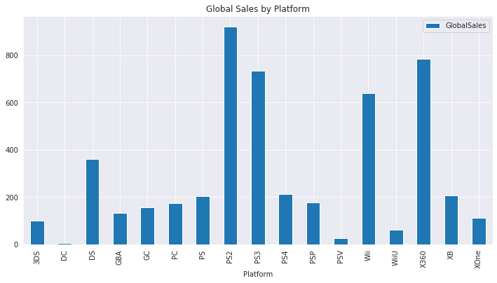

```python
cursor.execute('SELECT Platform, sum(GlobalSales) FROM videogame99 GROUP BY Platform')
query = cursor.fetchall()
rows = pd.DataFrame(query, columns=(['Platform', 'GlobalSales']))
sns.set_style("darkgrid")
rows.plot(x='Platform', y='GlobalSales',title='Global Sales by Platform', figsize = (12,6),  kind='bar')
```

This graph shows us the GlobalSales by platform. We can see that the ps2 is the platform where there was the most belly followed by X360, PS3 and Wii. The three main Publisher is SOny Playstation, Microsoft XBox and Nintendo.

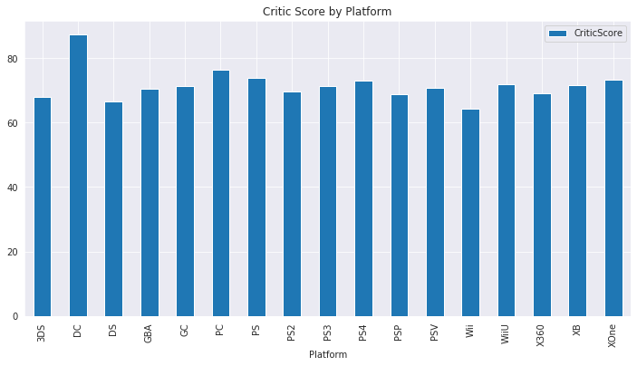

```python
cursor.execute('SELECT Platform, AVG(CriticScore) FROM videogame99 GROUP BY Platform')
query = cursor.fetchall()
rows = pd.DataFrame(query, columns=(['Platform', 'CriticScore']))
sns.set_style("darkgrid")
rows.plot(x='Platform',title='Critic Score by Platform',figsize = (12,6), kind='bar')
```

We can see that the games that received the best reviews are on the DC platform

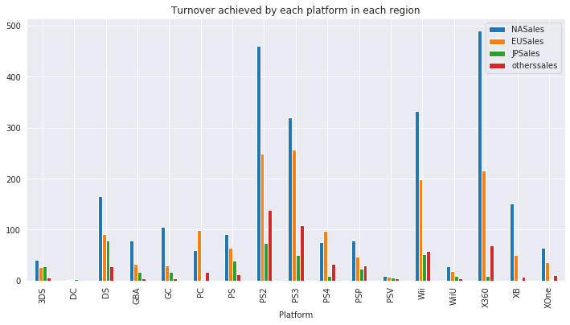

```python
cursor.execute('SELECT Platform, sum(NASales), sum(EUSales), sum(JPSales), sum(otherssales) FROM videogame99 GROUP BY Platform')
rquery = cursor.fetchall()
rrows = pd.DataFrame(rquery, columns=(['Platform', 'NASales', 'EUSales', 'JPSales', 'otherssales']))
sns.set_style("darkgrid")
rrows.plot(x='Platform',title='Turnover achieved by each platform in each region',figsize = (12,6), kind='bar')
```

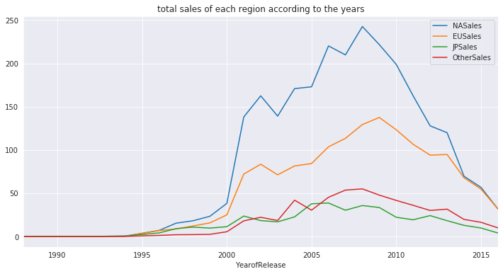

```python
cursor.execute('SELECT YearofRelease, sum(NASales), sum(EUSales), sum(JPSales), sum(OthersSales) FROM videogame99 GROUP BY YearofRelease')
rquery = cursor.fetchall()
rowss = pd.DataFrame(rquery,columns =(['YearofRelease','NASales','EUSales','JPSales','OtherSales']))
sns.set_style("darkgrid")
rowss.plot(x='YearofRelease',title='total sales of each region according to the years',figsize = (12,6))
```

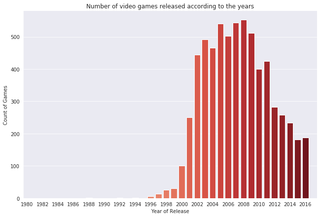

```python
cursor.execute('SELECT YearofRelease FROM videogame99')
rquery = cursor.fetchall()
rows = pd.DataFrame(rquery,columns=(['YearofRelease']))
years =np.arange(1980,2018)
gameyear = sns.factorplot(x="YearofRelease", data=rows, kind="count", palette="Reds",
                          size=6, aspect=1.5,order=years)
gameyear.set_xticklabels(step=2)
gameyear.set(xlabel = 'Year of Release',ylabel = 'Count of Games',title = 'Number of video games released according to the years')
```

Between 2002 and 2009, this is the period when there are the most video games that are released.This is explained by the release of several video game consoles at the same time

```python
cursor.execute('SELECT UserScore, CriticScore, GlobalSales FROM videogame99 ')
query = cursor.fetchall()
rowssss = pd.DataFrame(query, columns=(['UserScore','CriticScore','GlobalSales']))
UserScore_avg = rowssss['UserScore'].sum() / rowssss['UserScore'].count()
CriticScore_avg = rowssss['CriticScore'].sum() / rowssss['CriticScore'].count()
GlobalSales_avg = rowssss['GlobalSales'].sum() / rowssss['GlobalSales'].count()
print("UserScore_Average: " , UserScore_avg)
print("CriticScore_Average: " , CriticScore_avg)
print("GlobalSales_Average: " , GlobalSales_avg)
```

```
UserScore_Average:  7.203165261342232
CriticScore_Average:  70.41163692785105
GlobalSales_Average:  0.7775391769565821
```

```python
cursor.execute('SELECT  AVG(UserScore), AVG(CriticScore), AVG(GlobalSales) FROM videogame99')
query = cursor.fetchall()
rows = pd.DataFrame(query,columns=(['UserScore','CriticScore','GlobalSales']))
rows
```

|  | UserScore | CriticScore | GlobalSales |
| --- | --- | --- | --- |
| 0 | 7.203165 | 70.411637 | 0.777539 |

We can see here the average of UserScore, CriticScore and GlobalSales

```python
cursor.execute('SELECT Name,Platform, Publisher,CriticScore, UserScore,   MAX(GlobalSales) as count1 FROM videogame99 GROUP BY Name, Platform, Publisher, CriticScore, UserScore ORDER BY count1 DESC limit 1 ')
query = cursor.fetchall()
rows = pd.DataFrame(query, columns=(['Name', 'Platform','Publisher','CriticScore','UserScore','GlobalSales']))
rows
```

|  | Name | Platform | Publisher | CriticScore | UserScore | GlobalSales |
| --- | --- | --- | --- | --- | --- | --- |
| 0 | Wii Sports | Wii | Nintendo | 76.0 | 8.0 | 82.529999 |

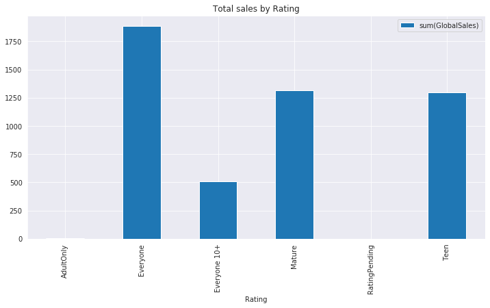

```python
cursor.execute('SELECT Rating, sum(GlobalSales) FROM videogame99 GROUP BY Rating')
query = cursor.fetchall()
rows = pd.DataFrame(query, columns =(['Rating', 'sum(GlobalSales)']))
rows.plot(x='Rating', y='sum(GlobalSales)',title='Total sales by Rating', figsize = (12,6), kind ='bar')
```

[output not shown]

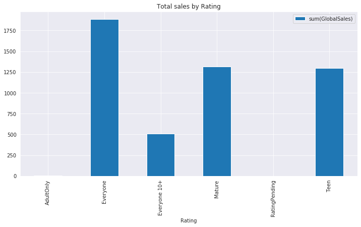

```python
cursor.execute('SELECT Rating, sum(GlobalSales) FROM videogame99 GROUP BY Rating')
query = cursor.fetchall()
rows = pd.DataFrame(query, columns =(['Rating', 'sum(GlobalSales)']))
rows.plot(x='Rating', y='sum(GlobalSales)',title='Total sales by Rating', figsize = (12,6), kind ='bar')
rows
```

The most successful games are games for everyone.

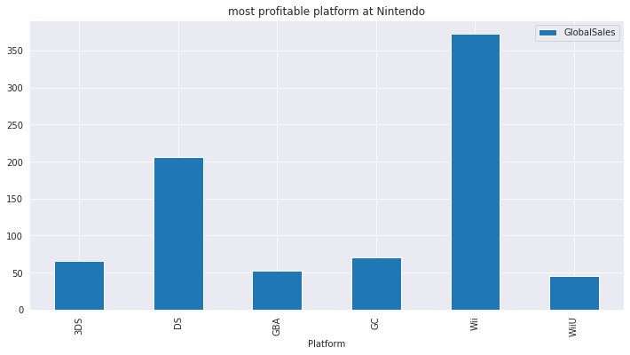

```python
cursor.execute('SELECT Platform, Publisher, SUM(GlobalSales) FROM videogame99 WHERE Publisher="Nintendo" GROUP BY Platform, Publisher')
Query = cursor.fetchall()
Rows = pd.DataFrame(Query, columns=(['Platform','Publisher','GlobalSales']))
Rows.plot(x='Platform',title='most profitable platform at Nintendo',figsize = (12,6),kind='bar')
```

For Nintendo, the most profitable platform is the Wii with video games that are sold at more than 350 million copies.

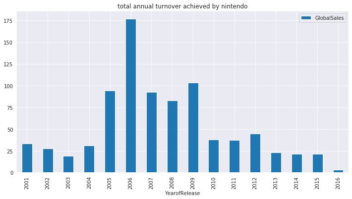

```python
cursor.execute('SELECT Publisher, YearofRelease, sum(GlobalSales) FROM video_game WHERE Publisher = "Nintendo" GROUP BY Publisher, YearofRelease')
query = cursor.fetchall()
query
rows = pd.DataFrame(query, columns=(['Publisher', 'YearofRelease', 'GlobalSales']))
rows.plot(x='YearofRelease',y='GlobalSales',title='total annual turnover achieved by nintendo',figsize = (12,6), kind ='bar')
```

We can see that the highest turnover for nintendo was in 2006. That's the same year the Wii was released.

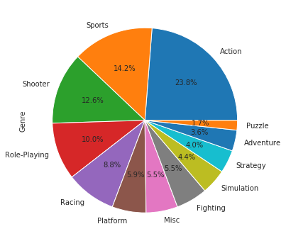

```python
cursor.execute('SELECT Genre FROM videogame99')
query = cursor.fetchall()
rows = pd.DataFrame(query, columns=(['Genre']))
plt.figure(figsize=(12,6))
rows['Genre'].value_counts().plot.pie(autopct='%1.1f%%')
```

One can see that action games are the most desired games any platform, tracking sports games, and shooting

```python
! pip install plotly==4.3.0
```

```python
import plotly.express as px
cursor.execute('SELECT Platform, SUM(UserCount) FROM videogame99 WHERE UserScore >= 8 GROUP BY Platform')
query = cursor.fetchall()
rows = pd.DataFrame(query,columns=(['Platform','SUM(UserCount)']))
fig = px.scatter(rows, x='Platform', y='SUM(UserCount)', title='Number of people who rated a game with a score of> = 8 per platform')
fig.show()
```

[interactive chart not shown]

We can see that generally, the PC is the platform where the users give the best notes to the games

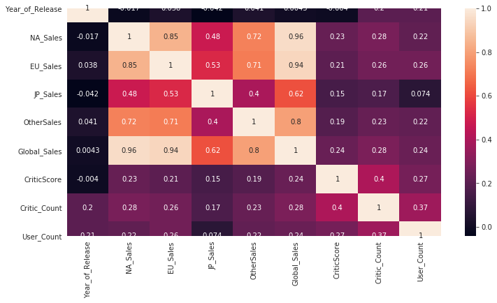

```python
correlation = df.corr()
plt.subplots(figsize = (12,6))
sns_plot = sns.heatmap(correlation,
                      xticklabels=correlation.columns.values,
                       yticklabels=correlation.columns.values,
                      annot = True)
plt.show()
```

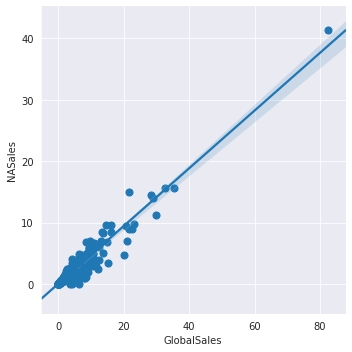

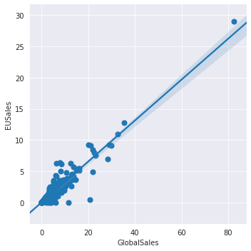

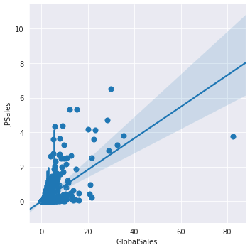

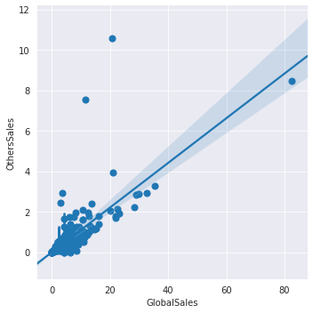

```python
cursor.execute('SELECT GlobalSales, NASales, EUSales, JPSales, OthersSales FROM videogame99')
rquery = cursor.fetchall()

rrows = pd.DataFrame(rquery, columns=(['GlobalSales','NASales','EUSales','JPSales','OthersSales']))

sns.lmplot(x="GlobalSales", y="NASales", data= rrows, x_estimator = np.mean);
sns.lmplot(x="GlobalSales", y="EUSales", data= rrows, x_estimator = np.mean);
sns.lmplot(x="GlobalSales", y="JPSales", data= rrows, x_estimator = np.mean);
sns.lmplot(x="GlobalSales", y="OthersSales", data= rrows, x_estimator = np.mean);
```